# TÍTOL DEL TREBALL

```r
TC_NETA_P5_OCUPACIO <- TC_BRUTA_P5_OCUPACIO[c("Directores/as y gerentes",
                                              "Profesionales, científicos/as e intelectuales",
                                              "Técnicos/as y profesionales de nivel medio",
                                              "Personal de apoyo administrativo",
                                              "Trabajadores/as de los servicios y vendedores/as de comercios y mercados",
                                              "Agricultores/as y trabajadores/as agropecuarios/as, forestales y pesqueros/as",
                                              "Oficiales/as, operarios/as y artesanos/as",
                                              "Operadores/as de instalaciones y máquinas y ensambladores/as",
                                              "Ocupaciones elementales",
                                              "Ocupaciones militares y cuerpos policiales",
                                              "Otra ocupación",
                                              "Jubilado o pensionista (anteriormente ha trabajado)",
                                              "Estudiante",
                                              "Trabajo doméstico no remunerado",
                                              "Otra situación inactiva",
                                              "Parados/as"),
                                            c("Nada",
                                              "Poco",
                                              "Bastante",
                                              "Mucho")]

TC_NETA_P5_OCUPACIO
```

```
##
##                                                                                 Nada
##   Directores/as y gerentes                                                        33
##   Profesionales, científicos/as e intelectuales                                   61
##   Técnicos/as y profesionales de nivel medio                                      32
##   Personal de apoyo administrativo                                                17
##   Trabajadores/as de los servicios y vendedores/as de comercios y mercados        54
##   Agricultores/as y trabajadores/as agropecuarios/as, forestales y pesqueros/as    9
##   Oficiales/as, operarios/as y artesanos/as                                       23
##   Operadores/as de instalaciones y máquinas y ensambladores/as                    10
##   Ocupaciones elementales                                                          9
##   Ocupaciones militares y cuerpos policiales                                       9
##   Otra ocupación                                                                   0
##   Jubilado o pensionista (anteriormente ha trabajado)                             51
##   Estudiante                                                                       9
##   Trabajo doméstico no remunerado                                                 20
##   Otra situación inactiva                                                         12
##   Parados/as                                                                      32
##
##                                                                                 Poco
##   Directores/as y gerentes                                                        97
##   Profesionales, científicos/as e intelectuales                                  389
##   Técnicos/as y profesionales de nivel medio                                     178
##   Personal de apoyo administrativo                                                96
##   Trabajadores/as de los servicios y vendedores/as de comercios y mercados       158
##   Agricultores/as y trabajadores/as agropecuarios/as, forestales y pesqueros/as   21
##   Oficiales/as, operarios/as y artesanos/as                                       55
##   Operadores/as de instalaciones y máquinas y ensambladores/as                    39
##   Ocupaciones elementales                                                         39
##   Ocupaciones militares y cuerpos policiales                                      31
##   Otra ocupación                                                                   1
##   Jubilado o pensionista (anteriormente ha trabajado)                            354
##   Estudiante                                                                      62
##   Trabajo doméstico no remunerado                                                 68
##   Otra situación inactiva                                                         56
##   Parados/as                                                                     152
##
##                                                                                 Bastante
##   Directores/as y gerentes                                                            53
##   Profesionales, científicos/as e intelectuales                                      275
```

[output cut: 17 more lines]

```
##   Profesionales, científicos/as e intelectuales                                   118
##   Técnicos/as y profesionales de nivel medio                                       37
##   Personal de apoyo administrativo                                                 22
##   Trabajadores/as de los servicios y vendedores/as de comercios y mercados         36
##   Agricultores/as y trabajadores/as agropecuarios/as, forestales y pesqueros/as     7
##   Oficiales/as, operarios/as y artesanos/as                                        16
##   Operadores/as de instalaciones y máquinas y ensambladores/as                      6
##   Ocupaciones elementales                                                          15
##   Ocupaciones militares y cuerpos policiales                                        3
##   Otra ocupación                                                                    1
##   Jubilado o pensionista (anteriormente ha trabajado)                              83
##   Estudiante                                                                       19
##   Trabajo doméstico no remunerado                                                  12
##   Otra situación inactiva                                                          11
##   Parados/as                                                                       37
```

```r
chisq.test(TC_NETA_P5_OCUPACIO)
```

```
##
##  Pearson's Chi-squared test
##
## data:  TC_NETA_P5_OCUPACIO
## X-squared = 104.31, df = 45, p-value = 1.308e-06
```

*Percentatges per fila per veure si hi ha algun patró*

```r
percentatges_fila_P5_OCUPACIO <- prop.table(TC_NETA_P5_OCUPACIO, margin = 1) * 100
print(round(percentatges_fila_P5_OCUPACIO, 2))
```

```
##
##                                                                                  Nada
##   Directores/as y gerentes                                                      15.42
##   Profesionales, científicos/as e intelectuales                                  7.24
##   Técnicos/as y profesionales de nivel medio                                     8.94
##   Personal de apoyo administrativo                                               8.54
##   Trabajadores/as de los servicios y vendedores/as de comercios y mercados      16.07
##   Agricultores/as y trabajadores/as agropecuarios/as, forestales y pesqueros/as 20.00
##   Oficiales/as, operarios/as y artesanos/as                                     19.66
##   Operadores/as de instalaciones y máquinas y ensambladores/as                  14.08
##   Ocupaciones elementales                                                       10.34
##   Ocupaciones militares y cuerpos policiales                                    16.98
##   Otra ocupación                                                                 0.00
##   Jubilado o pensionista (anteriormente ha trabajado)                            6.66
##   Estudiante                                                                     7.20
##   Trabajo doméstico no remunerado                                               14.93
##   Otra situación inactiva                                                       10.71
##   Parados/as                                                                    10.00
##
##                                                                                  Poco
##   Directores/as y gerentes                                                      45.33
##   Profesionales, científicos/as e intelectuales                                 46.14
##   Técnicos/as y profesionales de nivel medio                                    49.72
##   Personal de apoyo administrativo                                              48.24
##   Trabajadores/as de los servicios y vendedores/as de comercios y mercados      47.02
##   Agricultores/as y trabajadores/as agropecuarios/as, forestales y pesqueros/as 46.67
##   Oficiales/as, operarios/as y artesanos/as                                     47.01
##   Operadores/as de instalaciones y máquinas y ensambladores/as                  54.93
##   Ocupaciones elementales                                                       44.83
##   Ocupaciones militares y cuerpos policiales                                    58.49
##   Otra ocupación                                                                25.00
##   Jubilado o pensionista (anteriormente ha trabajado)                           46.21
##   Estudiante                                                                    49.60
##   Trabajo doméstico no remunerado                                               50.75
##   Otra situación inactiva                                                       50.00
##   Parados/as                                                                    47.50
##
##                                                                                 Bastante
##   Directores/as y gerentes                                                         24.77
##   Profesionales, científicos/as e intelectuales                                    32.62
```

[output cut: 17 more lines]

```
##   Profesionales, científicos/as e intelectuales                                 14.00
##   Técnicos/as y profesionales de nivel medio                                    10.34
##   Personal de apoyo administrativo                                              11.06
##   Trabajadores/as de los servicios y vendedores/as de comercios y mercados      10.71
##   Agricultores/as y trabajadores/as agropecuarios/as, forestales y pesqueros/as 15.56
##   Oficiales/as, operarios/as y artesanos/as                                     13.68
##   Operadores/as de instalaciones y máquinas y ensambladores/as                   8.45
##   Ocupaciones elementales                                                       17.24
##   Ocupaciones militares y cuerpos policiales                                     5.66
##   Otra ocupación                                                                25.00
##   Jubilado o pensionista (anteriormente ha trabajado)                           10.84
##   Estudiante                                                                    15.20
##   Trabajo doméstico no remunerado                                                8.96
##   Otra situación inactiva                                                        9.82
##   Parados/as                                                                    11.56
```

*Test chi-quadrat per veure si hi ha una associació significativa entre les dues variables categòriques*

```r
resultat_chi2_P5_OCUPACIO <- chisq.test(percentatges_fila_P5_OCUPACIO)
print(resultat_chi2_P5_OCUPACIO)
```

```
##
##  Pearson's Chi-squared test
##
## data:  percentatges_fila_P5_OCUPACIO
## X-squared = 108.59, df = 45, p-value = 3.558e-07
```

## Variable P6: Valoración de las contraprestaciones que se reciben personal y familiarmente por el pago a las administraciones públicas de los impuestos y cotizaciones

**Segons Classe social autopercebuda**

```r
BD_AGR_NETA_p6classe <- BD_AGR_TIDY %>%
  filter(!P6 %in% c(8, 9))

BD_AGR_NETA_p6classe <- BD_AGR_NETA_p6classe %>%
  filter(!CLASESUB %in% c(6,8, 9))

TC_BRUTA_P6_CLASESUB <- table(BD_AGR_NETA_p6classe$`CLASESUB Identificación subjetiva de clase`,
                              BD_AGR_NETA_p6classe$`P6 Valoración de las contraprestaciones que se reciben personal y familiarmente por el pago a las administraciones públicas de los impuestos y cotizaciones`)

TC_BRUTA_P6_CLASESUB
```

```
##
##                                         Más de lo que paga
##   Clase alta y media alta                               27
##   Clase baja/pobre                                      36
##   Clase media-baja                                      50
##   Clase media-media                                    137
##   Clase trabajadora/obrera/proletariado                 82
##
##                                         Más o menos lo que paga
##   Clase alta y media alta                                    56
##   Clase baja/pobre                                          102
##   Clase media-baja                                          144
##   Clase media-media                                         518
##   Clase trabajadora/obrera/proletariado                     154
##
##                                         Menos de lo que paga
##   Clase alta y media alta                                147
##   Clase baja/pobre                                       325
##   Clase media-baja                                       333
##   Clase media-media                                     1182
##   Clase trabajadora/obrera/proletariado                  199
```

```r
TC_NETA_P6_CLASESUB <- TC_BRUTA_P6_CLASESUB[c("Clase alta y media alta",
                                                 "Clase media-media",
                                                 "Clase media-baja",
                                                 "Clase trabajadora/obrera/proletariado",
                                                 "Clase baja/pobre"),
                                               c("Menos de lo que paga",
                                                 "Más o menos lo que paga",
                                                 "Más de lo que paga")]

TC_NETA_P6_CLASESUB
```

```
##
##                                         Menos de lo que paga
##   Clase alta y media alta                                147
##   Clase media-media                                     1182
##   Clase media-baja                                       333
##   Clase trabajadora/obrera/proletariado                  199
##   Clase baja/pobre                                       325
##
##                                         Más o menos lo que paga
##   Clase alta y media alta                                    56
##   Clase media-media                                         518
##   Clase media-baja                                          144
##   Clase trabajadora/obrera/proletariado                     154
##   Clase baja/pobre                                          102
##
##                                         Más de lo que paga
##   Clase alta y media alta                               27
##   Clase media-media                                    137
##   Clase media-baja                                      50
##   Clase trabajadora/obrera/proletariado                 82
##   Clase baja/pobre                                      36
```

```r
chisq.test(TC_NETA_P6_CLASESUB)
```

```
##
##  Pearson's Chi-squared test
##
## data:  TC_NETA_P6_CLASESUB
## X-squared = 91.369, df = 8, p-value = 2.452e-16
```

*Percentatges per fila per veure si hi ha algun patró*

```r
percentatges_fila_P6_CLASEUB <- prop.table(TC_NETA_P6_CLASESUB, margin = 1) * 100
print(round(percentatges_fila_P6_CLASEUB, 2))
```

```
##
##                                         Menos de lo que paga
##   Clase alta y media alta                              63.91
##   Clase media-media                                    64.34
##   Clase media-baja                                     63.19
##   Clase trabajadora/obrera/proletariado                45.75
##   Clase baja/pobre                                     70.19
##
##                                         Más o menos lo que paga
##   Clase alta y media alta                                 24.35
##   Clase media-media                                       28.20
##   Clase media-baja                                        27.32
##   Clase trabajadora/obrera/proletariado                   35.40
##   Clase baja/pobre                                        22.03
##
##                                         Más de lo que paga
##   Clase alta y media alta                            11.74
##   Clase media-media                                   7.46
##   Clase media-baja                                    9.49
##   Clase trabajadora/obrera/proletariado              18.85
##   Clase baja/pobre                                    7.78
```

*Test chi-quadrat per veure si hi ha una associació significativa entre les dues variables categòriques*

```r
resultat_chi2_P6_CLASEUB <- chisq.test(TC_NETA_P6_CLASESUB)
print(resultat_chi2_P6_CLASEUB)
```

```
##
##  Pearson's Chi-squared test
##
## data:  TC_NETA_P6_CLASESUB
## X-squared = 91.369, df = 8, p-value = 2.452e-16
```

**Segons Nivell d’Ingressos de la Llar**

```r
BD_AGR_NETA_p6ingresos <- BD_AGR_TIDY %>%
  filter(!P6 %in% c(8, 9))

BD_AGR_NETA_p6ingresos <- BD_AGR_NETA_p6ingresos %>%
  filter(!INGRESHOG %in% c(98,99))

TC_BRUTA_P6_NIVINGLL <- table(BD_AGR_NETA_p6ingresos$`INGRESHOG Nivel de ingresos netos del hogar`,
                              BD_AGR_NETA_p6ingresos$`P6 Valoración de las contraprestaciones que se reciben personal y familiarmente por el pago a las administraciones públicas de los impuestos y cotizaciones`)

print(TC_BRUTA_P6_NIVINGLL)
```

```
##
##                                      Más de lo que paga Más o menos lo que paga
##   De 1.201 a 1.800 €                                 46                     148
##   De 1.801 a 2.400 €                                 51                     185
##   De 2.401 a 3.000 €                                 76                     162
##   De 3.001 a 4.500 €                                 92                     235
##   De 301 a 600 €                                      4                      27
##   De 4.501 a 6.000 €                                 36                      97
##   De 601 a 900 €                                      8                      40
##   De 901 a 1.200 €                                   24                      90
##   Más de 6.000 €                                     14                      30
##   Menos o igual a 300 €                               1                       0
##   No tiene/n ingresos de ningún tipo                  1                       3
##
##                                      Menos de lo que paga
##   De 1.201 a 1.800 €                                  321
##   De 1.801 a 2.400 €                                  414
##   De 2.401 a 3.000 €                                  358
##   De 3.001 a 4.500 €                                  474
##   De 301 a 600 €                                       35
##   De 4.501 a 6.000 €                                  218
##   De 601 a 900 €                                       88
##   De 901 a 1.200 €                                    177
##   Más de 6.000 €                                      179
##   Menos o igual a 300 €                                 7
##   No tiene/n ingresos de ningún tipo                    6
```

```r
TC_NETA_P6_NIVINGLL <- TC_BRUTA_P6_NIVINGLL[c("No tiene/n ingresos de ningún tipo",
                                              "Menos o igual a 300 €",
                                              "De 301 a 600 €",
                                              "De 601 a 900 €",
                                              "De 901 a 1.200 €",
                                              "De 1.201 a 1.800 €",
                                              "De 1.801 a 2.400 €",
                                              "De 2.401 a 3.000 €",
                                              "De 3.001 a 4.500 €",
                                              "De 4.501 a 6.000 €",
                                              "Más de 6.000 €"),
                                            c("Menos de lo que paga",
                                              "Más o menos lo que paga",
                                              "Más de lo que paga")]

TC_NETA_P6_NIVINGLL
```

```
##
##                                      Menos de lo que paga
##   No tiene/n ingresos de ningún tipo                    6
##   Menos o igual a 300 €                                 7
##   De 301 a 600 €                                       35
##   De 601 a 900 €                                       88
##   De 901 a 1.200 €                                    177
##   De 1.201 a 1.800 €                                  321
##   De 1.801 a 2.400 €                                  414
##   De 2.401 a 3.000 €                                  358
##   De 3.001 a 4.500 €                                  474
##   De 4.501 a 6.000 €                                  218
##   Más de 6.000 €                                      179
##
##                                      Más o menos lo que paga Más de lo que paga
##   No tiene/n ingresos de ningún tipo                       3                  1
##   Menos o igual a 300 €                                    0                  1
##   De 301 a 600 €                                          27                  4
##   De 601 a 900 €                                          40                  8
##   De 901 a 1.200 €                                        90                 24
##   De 1.201 a 1.800 €                                     148                 46
##   De 1.801 a 2.400 €                                     185                 51
##   De 2.401 a 3.000 €                                     162                 76
##   De 3.001 a 4.500 €                                     235                 92
##   De 4.501 a 6.000 €                                      97                 36
##   Más de 6.000 €                                          30                 14
```

```r
chisq.test(TC_NETA_P6_NIVINGLL)
```

```
##
##  Pearson's Chi-squared test
##
## data:  TC_NETA_P6_NIVINGLL
## X-squared = 57.796, df = 20, p-value = 1.553e-05
```

*Percentatges per fila per veure si hi ha algun patró*

```r
percentatges_fila_P6_NIVINGLL <- prop.table(TC_NETA_P6_NIVINGLL, margin = 1) * 100
print(round(percentatges_fila_P6_NIVINGLL, 2))
```

```
##
##                                      Menos de lo que paga
##   No tiene/n ingresos de ningún tipo                60.00
##   Menos o igual a 300 €                             87.50
##   De 301 a 600 €                                    53.03
##   De 601 a 900 €                                    64.71
##   De 901 a 1.200 €                                  60.82
##   De 1.201 a 1.800 €                                62.33
##   De 1.801 a 2.400 €                                63.69
##   De 2.401 a 3.000 €                                60.07
##   De 3.001 a 4.500 €                                59.18
##   De 4.501 a 6.000 €                                62.11
##   Más de 6.000 €                                    80.27
##
##                                      Más o menos lo que paga Más de lo que paga
##   No tiene/n ingresos de ningún tipo                   30.00              10.00
##   Menos o igual a 300 €                                 0.00              12.50
##   De 301 a 600 €                                       40.91               6.06
##   De 601 a 900 €                                       29.41               5.88
##   De 901 a 1.200 €                                     30.93               8.25
##   De 1.201 a 1.800 €                                   28.74               8.93
##   De 1.801 a 2.400 €                                   28.46               7.85
##   De 2.401 a 3.000 €                                   27.18              12.75
##   De 3.001 a 4.500 €                                   29.34              11.49
##   De 4.501 a 6.000 €                                   27.64              10.26
##   Más de 6.000 €                                       13.45               6.28
```

*Test chi-quadrat per veure si hi ha una associació significativa entre les dues variables categòriques*

```r
resultat_chi2_P6_NIVINGLL <- chisq.test(TC_NETA_P6_NIVINGLL)
print(resultat_chi2_P6_NIVINGLL)
```

```
##
##  Pearson's Chi-squared test
##
## data:  TC_NETA_P6_NIVINGLL
## X-squared = 57.796, df = 20, p-value = 1.553e-05
```

**Segons Nivell d’Estudis**

```r
BD_AGR_NETA_p6_NIVEST <- BD_AGR_TIDY %>%
  filter(!P6 %in% c(8, 9))

BD_AGR_NETA_p6_NIVEST <- BD_AGR_NETA_p6_NIVEST %>%
  filter(!ESTUDIOS %in% c(7,9))

TC_BRUTA_P6_NIVEST <- table(BD_AGR_NETA_p6_NIVEST$`ESTUDIOS Estudios de la persona entrevistada`,
                            BD_AGR_NETA_p6_NIVEST$`P6 Valoración de las contraprestaciones que se reciben personal y familiarmente por el pago a las administraciones públicas de los impuestos y cotizaciones`)

print(TC_BRUTA_P6_NIVEST)
```

```
##
##                       Más de lo que paga Más o menos lo que paga
##   F.P.                                64                     183
##   Primaria                             8                      24
##   Secundaria 1ª etapa                 39                     106
##   Secundaria 2ª etapa                 52                     168
##   Sin estudios                         2                      10
##   Superiores                         189                     555
##
##                       Menos de lo que paga
##   F.P.                                 479
##   Primaria                              69
##   Secundaria 1ª etapa                  285
##   Secundaria 2ª etapa                  332
##   Sin estudios                          17
##   Superiores                          1189
```

```r
TC_NETA_P6_NIVEST <- TC_BRUTA_P6_NIVEST[c("Sin estudios",
                                             "Primaria",
                                             "Secundaria 1ª etapa",
                                             "Secundaria 2ª etapa",
                                             "F.P.",
                                             "Superiores"),
                                            c("Menos de lo que paga",
                                              "Más o menos lo que paga",
                                              "Más de lo que paga")]

TC_NETA_P6_NIVEST
```

```
##
##                       Menos de lo que paga Más o menos lo que paga
##   Sin estudios                          17                      10
##   Primaria                              69                      24
##   Secundaria 1ª etapa                  285                     106
##   Secundaria 2ª etapa                  332                     168
##   F.P.                                 479                     183
##   Superiores                          1189                     555
##
##                       Más de lo que paga
##   Sin estudios                         2
##   Primaria                             8
##   Secundaria 1ª etapa                 39
##   Secundaria 2ª etapa                 52
##   F.P.                                64
##   Superiores                         189
```

```r
chisq.test(TC_NETA_P6_NIVEST)
```

```
##
##  Pearson's Chi-squared test
##
## data:  TC_NETA_P6_NIVEST
## X-squared = 11.04, df = 10, p-value = 0.3544
```

*Percentatges per fila per veure si hi ha algun patró*

```r
percentatges_fila_P6_NIVEST <- prop.table(TC_NETA_P6_NIVEST, margin = 1) * 100
print(round(percentatges_fila_P6_NIVEST, 2))
```

```
##
##                       Menos de lo que paga Más o menos lo que paga
##   Sin estudios                       58.62                   34.48
##   Primaria                           68.32                   23.76
##   Secundaria 1ª etapa                66.28                   24.65
##   Secundaria 2ª etapa                60.14                   30.43
##   F.P.                               65.98                   25.21
##   Superiores                         61.51                   28.71
##
##                       Más de lo que paga
##   Sin estudios                      6.90
##   Primaria                          7.92
##   Secundaria 1ª etapa               9.07
##   Secundaria 2ª etapa               9.42
##   F.P.                              8.82
##   Superiores                        9.78
```

*Test chi-quadrat per veure si hi ha una associació significativa entre les dues variables categòriques*

```r
resultat_chi2_P6_NIVEST <- chisq.test(percentatges_fila_P6_NIVEST)
print(resultat_chi2_P6_NIVEST)
```

```
##
##  Pearson's Chi-squared test
##
## data:  percentatges_fila_P6_NIVEST
## X-squared = 4.9163, df = 10, p-value = 0.8967
```

**Segons Ocupació**

```r
BD_AGR_NETA_p6_OCUPACIO <- BD_AGR_TIDY %>%
  filter(!P6 %in% c(8, 9))

BD_AGR_NETA_p6_OCUPACIO <- BD_AGR_NETA_p6_OCUPACIO %>%
  filter(!CNO11R %in% c(99))

TC_BRUTA_P6_OCUPACIO <- table(BD_AGR_NETA_p6_OCUPACIO$`CNO11R Población activa e inactiva`,
                              BD_AGR_NETA_p6_OCUPACIO$`P6 Valoración de las contraprestaciones que se reciben personal y familiarmente por el pago a las administraciones públicas de los impuestos y cotizaciones`)

print(TC_BRUTA_P6_OCUPACIO)
```

```
##
##                                                                                 Más de lo que paga
##   Agricultores/as y trabajadores/as agropecuarios/as, forestales y pesqueros/as                  3
##   Directores/as y gerentes                                                                      15
##   Estudiante                                                                                    10
##   Jubilado o pensionista (anteriormente ha trabajado)                                          100
##   Ocupaciones elementales                                                                        7
##   Ocupaciones militares y cuerpos policiales                                                     1
##   Oficiales/as, operarios/as y artesanos/as                                                     11
##   Operadores/as de instalaciones y máquinas y ensambladores/as                                   7
##   Otra ocupación                                                                                 1
##   Otra situación inactiva                                                                        6
##   Parados/as                                                                                    25
##   Personal de apoyo administrativo                                                              21
##   Profesionales, científicos/as e intelectuales                                                 92
##   Técnicos/as y profesionales de nivel medio                                                    29
##   Trabajadores/as de los servicios y vendedores/as de comercios y mercados                      20
##   Trabajo doméstico no remunerado                                                                5
##
##                                                                                 Más o menos lo que paga
##   Agricultores/as y trabajadores/as agropecuarios/as, forestales y pesqueros/as                       7
##   Directores/as y gerentes                                                                           31
##   Estudiante                                                                                         46
##   Jubilado o pensionista (anteriormente ha trabajado)                                               271
##   Ocupaciones elementales                                                                            25
##   Ocupaciones militares y cuerpos policiales                                                          9
##   Oficiales/as, operarios/as y artesanos/as                                                          24
##   Operadores/as de instalaciones y máquinas y ensambladores/as                                       13
##   Otra ocupación                                                                                      1
##   Otra situación inactiva                                                                            36
##   Parados/as                                                                                        103
##   Personal de apoyo administrativo                                                                   57
##   Profesionales, científicos/as e intelectuales                                                     220
##   Técnicos/as y profesionales de nivel medio                                                         78
##   Trabajadores/as de los servicios y vendedores/as de comercios y mercados                           81
##   Trabajo doméstico no remunerado                                                                    43
##
##                                                                                 Menos de lo que paga
##   Agricultores/as y trabajadores/as agropecuarios/as, forestales y pesqueros/as                   35
##   Directores/as y gerentes                                                                       166
##   Estudiante                                                                                      65
##   Jubilado o pensionista (anteriormente ha trabajado)                                            391
##   Ocupaciones elementales                                                                         52
##   Ocupaciones militares y cuerpos policiales                                                      43
##   Oficiales/as, operarios/as y artesanos/as                                                       82
##   Operadores/as de instalaciones y máquinas y ensambladores/as                                    52
##   Otra ocupación                                                                                   2
##   Otra situación inactiva                                                                         68
##   Parados/as                                                                                     188
##   Personal de apoyo administrativo                                                               121
##   Profesionales, científicos/as e intelectuales                                                  526
##   Técnicos/as y profesionales de nivel medio                                                     250
##   Trabajadores/as de los servicios y vendedores/as de comercios y mercados                       232
##   Trabajo doméstico no remunerado                                                                 83
```

```r
TC_NETA_P6_OCUPACIO <- TC_BRUTA_P6_OCUPACIO[c("Directores/as y gerentes",
                                              "Profesionales, científicos/as e intelectuales",
                                              "Técnicos/as y profesionales de nivel medio",
                                              "Personal de apoyo administrativo",
                                              "Trabajadores/as de los servicios y vendedores/as de comercios y mercados",
                                              "Agricultores/as y trabajadores/as agropecuarios/as, forestales y pesqueros/as",
                                              "Oficiales/as, operarios/as y artesanos/as",
                                              "Operadores/as de instalaciones y máquinas y ensambladores/as",
                                              "Ocupaciones elementales",
                                              "Ocupaciones militares y cuerpos policiales",
                                              "Otra ocupación",
                                              "Jubilado o pensionista (anteriormente ha trabajado)",
                                              "Estudiante",
                                              "Trabajo doméstico no remunerado",
                                              "Otra situación inactiva",
                                              "Parados/as"),
                                        c("Menos de lo que paga",
                                          "Más o menos lo que paga",
                                          "Más de lo que paga")]

TC_NETA_P6_OCUPACIO
```

```
##
##                                                                                 Menos de lo que paga
##   Directores/as y gerentes                                                                       166
##   Profesionales, científicos/as e intelectuales                                                  526
##   Técnicos/as y profesionales de nivel medio                                                     250
##   Personal de apoyo administrativo                                                               121
##   Trabajadores/as de los servicios y vendedores/as de comercios y mercados                       232
##   Agricultores/as y trabajadores/as agropecuarios/as, forestales y pesqueros/as                   35
##   Oficiales/as, operarios/as y artesanos/as                                                       82
##   Operadores/as de instalaciones y máquinas y ensambladores/as                                    52
##   Ocupaciones elementales                                                                         52
##   Ocupaciones militares y cuerpos policiales                                                      43
##   Otra ocupación                                                                                   2
##   Jubilado o pensionista (anteriormente ha trabajado)                                            391
##   Estudiante                                                                                      65
##   Trabajo doméstico no remunerado                                                                 83
##   Otra situación inactiva                                                                         68
##   Parados/as                                                                                     188
##
##                                                                                 Más o menos lo que paga
##   Directores/as y gerentes                                                                           31
##   Profesionales, científicos/as e intelectuales                                                     220
##   Técnicos/as y profesionales de nivel medio                                                         78
##   Personal de apoyo administrativo                                                                   57
##   Trabajadores/as de los servicios y vendedores/as de comercios y mercados                           81
##   Agricultores/as y trabajadores/as agropecuarios/as, forestales y pesqueros/as                       7
##   Oficiales/as, operarios/as y artesanos/as                                                          24
##   Operadores/as de instalaciones y máquinas y ensambladores/as                                       13
##   Ocupaciones elementales                                                                            25
##   Ocupaciones militares y cuerpos policiales                                                          9
##   Otra ocupación                                                                                      1
##   Jubilado o pensionista (anteriormente ha trabajado)                                               271
##   Estudiante                                                                                         46
##   Trabajo doméstico no remunerado                                                                    43
##   Otra situación inactiva                                                                            36
##   Parados/as                                                                                        103
##
##                                                                                 Más de lo que paga
##   Directores/as y gerentes                                                                      15
##   Profesionales, científicos/as e intelectuales                                                 92
##   Técnicos/as y profesionales de nivel medio                                                    29
##   Personal de apoyo administrativo                                                              21
##   Trabajadores/as de los servicios y vendedores/as de comercios y mercados                      20
##   Agricultores/as y trabajadores/as agropecuarios/as, forestales y pesqueros/as                  3
##   Oficiales/as, operarios/as y artesanos/as                                                     11
##   Operadores/as de instalaciones y máquinas y ensambladores/as                                   7
##   Ocupaciones elementales                                                                        7
##   Ocupaciones militares y cuerpos policiales                                                     1
##   Otra ocupación                                                                                 1
##   Jubilado o pensionista (anteriormente ha trabajado)                                          100
##   Estudiante                                                                                    10
##   Trabajo doméstico no remunerado                                                                5
##   Otra situación inactiva                                                                        6
##   Parados/as                                                                                    25
```

```r
chisq.test(TC_NETA_P6_OCUPACIO)
```

```
##
##  Pearson's Chi-squared test
##
## data:  TC_NETA_P6_OCUPACIO
## X-squared = 125.13, df = 30, p-value = 1.393e-13
```

*Percentatges per fila per veure si hi ha algun patró*

```r
percentatges_fila_P6_OCUPACIO <- prop.table(TC_NETA_P6_OCUPACIO, margin = 1) * 100
print(round(percentatges_fila_P6_OCUPACIO, 2))
```

```
##
##                                                                                 Menos de lo que paga
##   Directores/as y gerentes                                                                     78.30
##   Profesionales, científicos/as e intelectuales                                                62.77
##   Técnicos/as y profesionales de nivel medio                                                   70.03
##   Personal de apoyo administrativo                                                             60.80
##   Trabajadores/as de los servicios y vendedores/as de comercios y mercados                     69.67
##   Agricultores/as y trabajadores/as agropecuarios/as, forestales y pesqueros/as                77.78
##   Oficiales/as, operarios/as y artesanos/as                                                    70.09
##   Operadores/as de instalaciones y máquinas y ensambladores/as                                 72.22
##   Ocupaciones elementales                                                                      61.90
##   Ocupaciones militares y cuerpos policiales                                                   81.13
##   Otra ocupación                                                                               50.00
##   Jubilado o pensionista (anteriormente ha trabajado)                                          51.31
##   Estudiante                                                                                   53.72
##   Trabajo doméstico no remunerado                                                              63.36
##   Otra situación inactiva                                                                      61.82
##   Parados/as                                                                                   59.49
##
##                                                                                 Más o menos lo que paga
##   Directores/as y gerentes                                                                        14.62
##   Profesionales, científicos/as e intelectuales                                                   26.25
##   Técnicos/as y profesionales de nivel medio                                                      21.85
##   Personal de apoyo administrativo                                                                28.64
##   Trabajadores/as de los servicios y vendedores/as de comercios y mercados                        24.32
##   Agricultores/as y trabajadores/as agropecuarios/as, forestales y pesqueros/as                   15.56
##   Oficiales/as, operarios/as y artesanos/as                                                       20.51
##   Operadores/as de instalaciones y máquinas y ensambladores/as                                    18.06
##   Ocupaciones elementales                                                                         29.76
##   Ocupaciones militares y cuerpos policiales                                                      16.98
##   Otra ocupación                                                                                  25.00
##   Jubilado o pensionista (anteriormente ha trabajado)                                             35.56
##   Estudiante                                                                                      38.02
##   Trabajo doméstico no remunerado                                                                 32.82
##   Otra situación inactiva                                                                         32.73
##   Parados/as                                                                                      32.59
##
##                                                                                 Más de lo que paga
##   Directores/as y gerentes                                                                    7.08
##   Profesionales, científicos/as e intelectuales                                              10.98
##   Técnicos/as y profesionales de nivel medio                                                  8.12
##   Personal de apoyo administrativo                                                           10.55
##   Trabajadores/as de los servicios y vendedores/as de comercios y mercados                    6.01
##   Agricultores/as y trabajadores/as agropecuarios/as, forestales y pesqueros/as               6.67
##   Oficiales/as, operarios/as y artesanos/as                                                   9.40
##   Operadores/as de instalaciones y máquinas y ensambladores/as                                9.72
##   Ocupaciones elementales                                                                     8.33
##   Ocupaciones militares y cuerpos policiales                                                  1.89
##   Otra ocupación                                                                             25.00
##   Jubilado o pensionista (anteriormente ha trabajado)                                        13.12
##   Estudiante                                                                                  8.26
##   Trabajo doméstico no remunerado                                                             3.82
##   Otra situación inactiva                                                                     5.45
##   Parados/as                                                                                  7.91
```

*Test chi-quadrat per veure si hi ha una associació significativa entre les dues variables categòriques*

```r
resultat_chi2_P6_OCUPACIO <- chisq.test(percentatges_fila_P6_OCUPACIO)
print(resultat_chi2_P6_OCUPACIO)
```

```
##
##  Pearson's Chi-squared test
##
## data:  percentatges_fila_P6_OCUPACIO
## X-squared = 96.447, df = 30, p-value = 6.701e-09
```

## Anàlisi dels Residus Estandarditzats

**Variable P5**

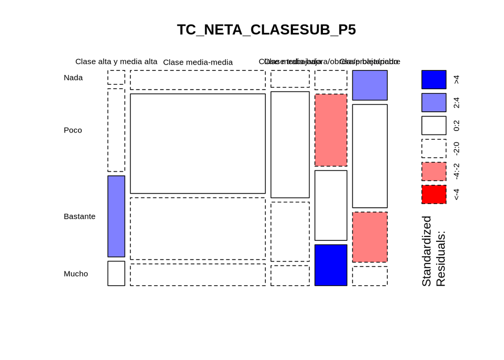

```r
mosaicplot(TC_NETA_CLASESUB_P5, shade = TRUE, las = 1)
```

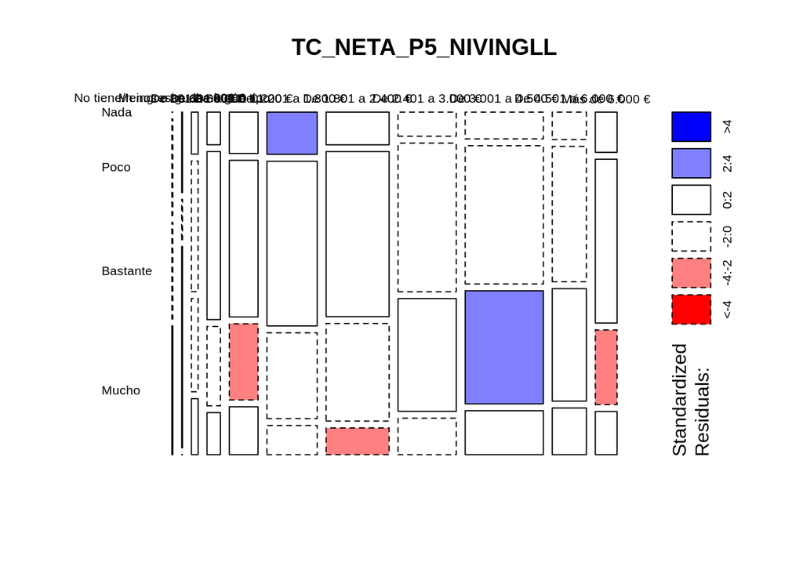

```r
mosaicplot(TC_NETA_P5_NIVINGLL, shade = TRUE, las = 1)
```

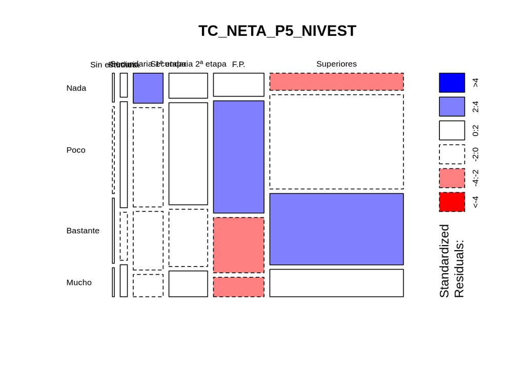

```r
mosaicplot(TC_NETA_P5_NIVEST, shade = TRUE, las = 1)
```

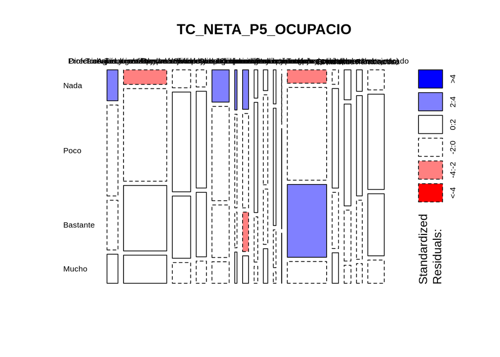

```r
mosaicplot(TC_NETA_P5_OCUPACIO, shade = TRUE, las = 1)
```

**Variable P6**

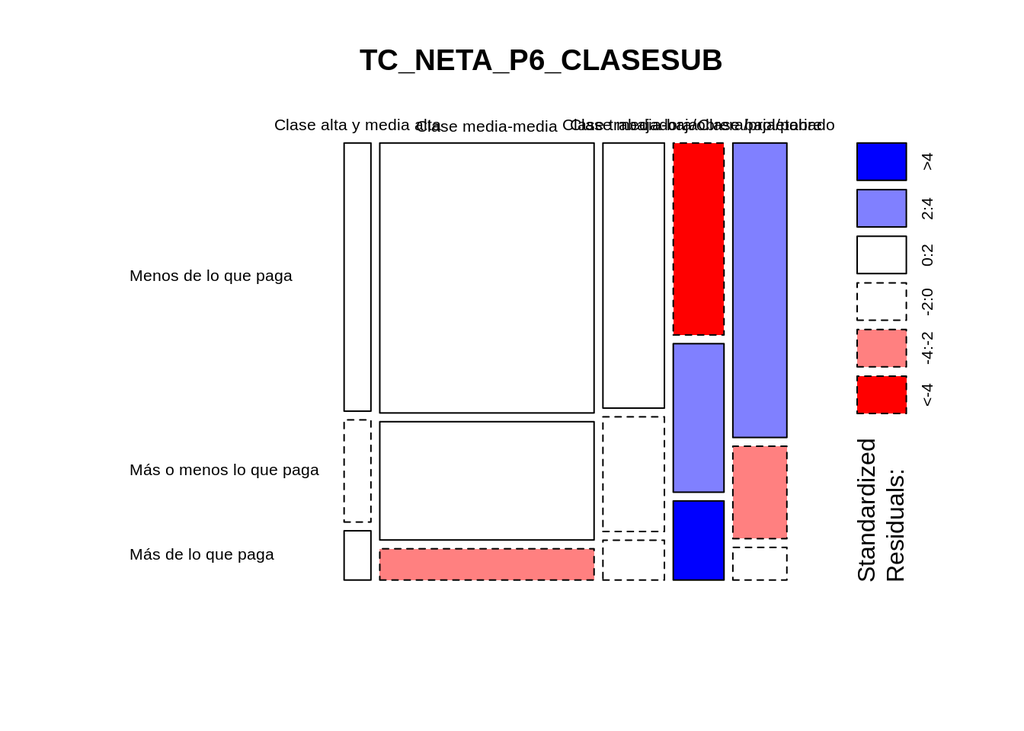

```r
mosaicplot(TC_NETA_P6_CLASESUB, shade = TRUE, las = 1)
```

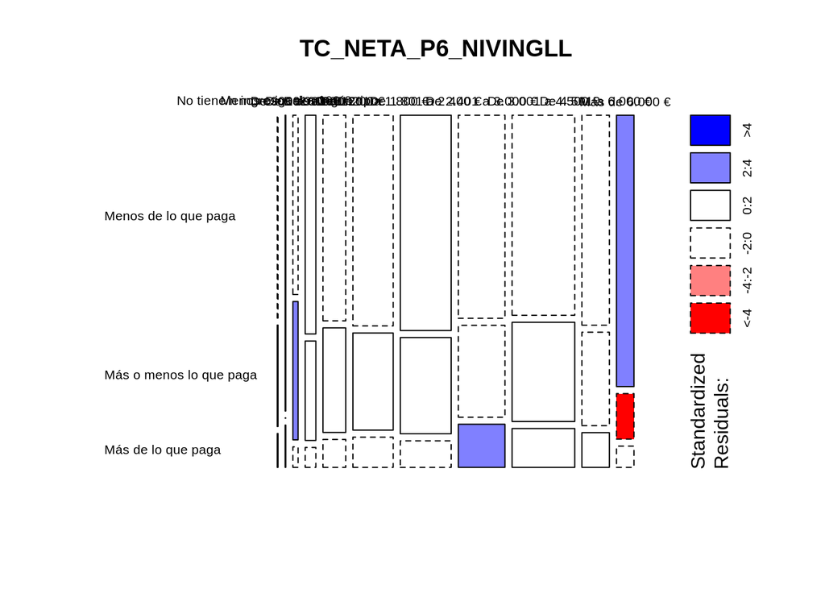

```r
mosaicplot(TC_NETA_P6_NIVINGLL, shade = TRUE, las = 1)
```

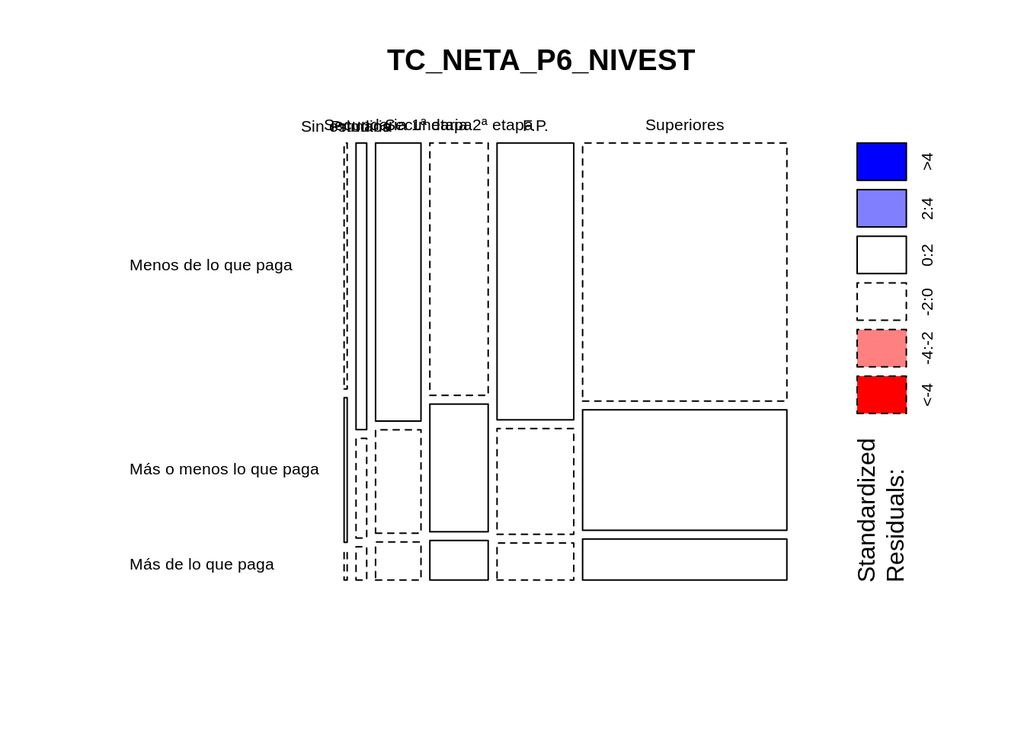

```r
mosaicplot(TC_NETA_P6_NIVEST, shade = TRUE, las = 1)
```

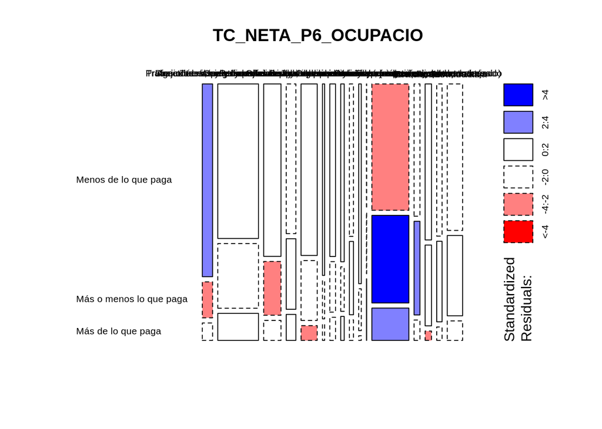

```r
mosaicplot(TC_NETA_P6_OCUPACIO, shade = TRUE, las = 1)
```